# HOMEWORK 4 DATA 2

```r
          temp=data.table(Rep=1,Method="svm",recall=recallvalue)
      overallresults=rbind(overallresults,temp)
      temp2=data.table(Rep=1,Method="svm",accuracy=accuracy.percent)
      overallresults2=rbind(overallresults2,temp2)
```

```r
 #random forest
    train_nores<-train[,1:23]
    rf_tune<-tuneRF(train_nores, train$`default payment next month`, doBest = TRUE)
```

```
## mtry = 4  OOB error = 19.66%
## Searching left ...
## mtry = 2     OOB error = 19.86%
## -0.01017442 0.05
## Searching right ...
## mtry = 8     OOB error = 20.46%
## -0.04069767 0.05
```

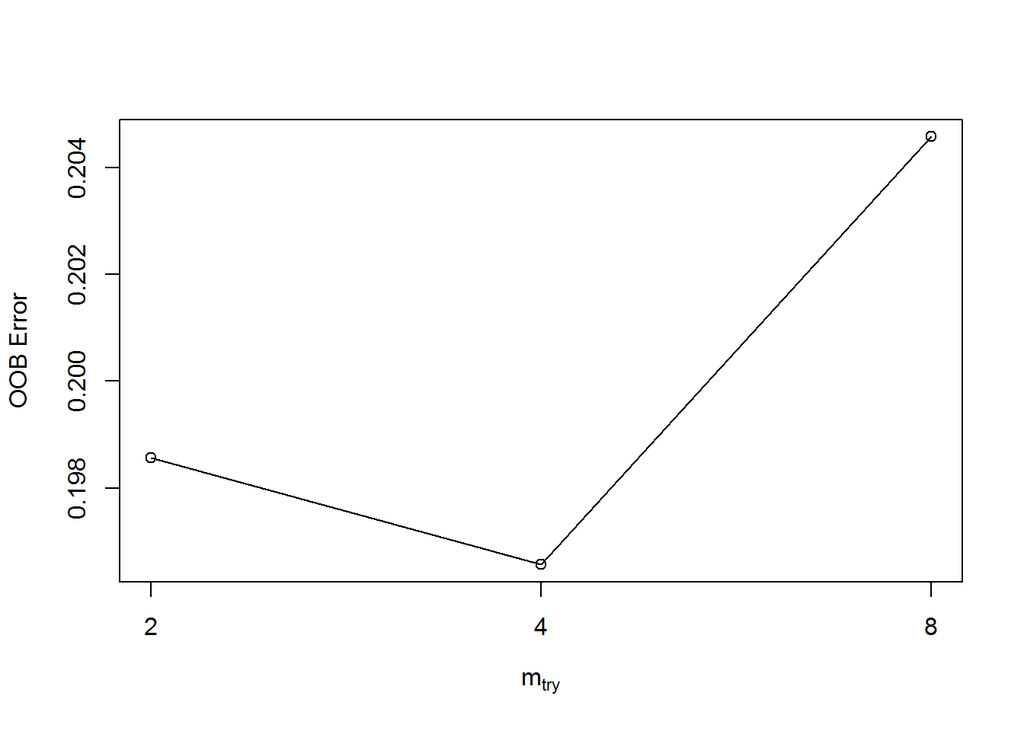

```r
    rfmodel<-randomForest(`default payment next month`~., data = train, na.action=na.exclude, ntree=500, nodesize=5 , mtry=rf_tune$mtry)
    rfpredicttrain<-predict(rfmodel, train)
    confusion.matrix <- table(train$`default payment next month`, rfpredicttrain)
    print(confusion.matrix)
```

```
##    rfpredicttrain
##        0    1
##   0 2736    5
##   1  103  656
```

```r
    accuracy.percent <- 100*sum(diag(confusion.matrix))/sum(confusion.matrix)
    print(paste("accuracy_train:",accuracy.percent,"%"))
```

```
## [1] "accuracy_train: 96.9142857142857 %"
```

```r
    recallvalue<-100*confusion.matrix[2,2]/sum(confusion.matrix[2,])
   print(paste("recall_train:",recallvalue,"%"))
```

```
## [1] "recall_train: 86.429512516469 %"
```

```r
   rfpredict<-predict(rfmodel, test)
   confusion.matrix <- table(test$`default payment next month`, rfpredict)
   print(confusion.matrix)
```

```
##    rfpredict
##        0    1
##   0 1074   78
##   1  240  108
```

```r
   accuracy.percent <- 100*sum(diag(confusion.matrix))/sum(confusion.matrix)
   print(paste("accuracy:",accuracy.percent,"%"))
```

```
## [1] "accuracy: 78.8 %"
```

```r
   recallvalue<-100*confusion.matrix[2,2]/sum(confusion.matrix[2,])
   print(paste("recall:",recallvalue,"%"))
```

```
## [1] "recall: 31.0344827586207 %"
```

```r
     temp=data.table(Rep=1,Method="rf",recall=recallvalue)
     overallresults=rbind(overallresults,temp)
     temp2=data.table(Rep=1,Method="rf",accuracy=accuracy.percent)
     overallresults2=rbind(overallresults2,temp2)
```

```r
#gradient boosting


    gbmGrid <-  expand.grid(interaction.depth = c(1, 5, 9),
                            n.trees = c(300,500,700),
                            shrinkage = c(0.1,0.3,0.5),
                            n.minobsinnode = 10)

    gbmFit <- train( `default payment next month`~ ., data = train[1:1000,],
                    method = "gbm",
                    verbose = FALSE,
                    tuneGrid = gbmGrid)

    gbmpredicttrain<-predict(gbmFit, train[1:1000,])
    confusion.matrix <- table(train[1:1000,]$`default payment next month`, gbmpredicttrain)
    print(confusion.matrix)
```

```
##    gbmpredicttrain
##       0   1
##   0 739  32
##   1 139  90
```

```r
    accuracy.percent <- 100*sum(diag(confusion.matrix))/sum(confusion.matrix)
    print(paste("accuracy_train:",accuracy.percent,"%"))
```

```
## [1] "accuracy_train: 82.9 %"
```

```r
    recallvalue<-100*confusion.matrix[2,2]/sum(confusion.matrix[2,])
    print(paste("recall_train:",recallvalue,"%"))
```

```
## [1] "recall_train: 39.3013100436681 %"
```

```r
   gbmFit$bestTune
```

```
##   n.trees interaction.depth shrinkage n.minobsinnode
## 1     300                 1       0.1             10
```

```r
    gbmpredict<-predict(gbmFit, test[1:500,])
    confusion.matrix <- table(test[1:500,]$`default payment next month`, gbmpredict)
    print(confusion.matrix)
```

```
##    gbmpredict
##       0   1
##   0 367  26
##   1  82  25
```

```r
    accuracy.percent <- 100*sum(diag(confusion.matrix))/sum(confusion.matrix)
    print(paste("accuracy:",accuracy.percent,"%"))
```

```
## [1] "accuracy: 78.4 %"
```

```r
    recallvalue<-100*confusion.matrix[2,2]/sum(confusion.matrix[2,])
    print(paste("recall:",recallvalue,"%"))
```

```
## [1] "recall: 23.3644859813084 %"
```

```r
    temp=data.table(Rep=1,Method="gbm",recall=recallvalue)
    overallresults=rbind(overallresults,temp)
    temp2=data.table(Rep=1,Method="gbm",accuracy=accuracy.percent)
    overallresults2=rbind(overallresults2,temp2)
```

Lastly, gradient boosting model is built for the data. Depth, learning rate and number of trees are tuned by creating a grid and then put it into the train function.The best parameters obtained are n.trees=300, interaction.depth=1, and shrinkage=0.1. Training error can be seen as 1-0.82=0.18 and test error can be seen as 1-0.78=0.22 based on accuracies. and recall values are 39% for train and 23% for test data.

```r
#to wide format

wideTableResults=dcast(overallresults, Rep ~ Method, value.var = "recall")
wideTableResults  #recall
```

```
##    Rep      gbm penalized       rf    rpart      svm
## 1:   1 23.36449  20.68966 31.03448 26.72414 35.91954
```

```r
wideTableResults2=dcast(overallresults2, Rep ~ Method, value.var = "accuracy")
wideTableResults2  #accuracy
```

```
##    Rep  gbm penalized   rf    rpart      svm
## 1:   1 78.4      78.2 78.8 78.86667 65.13333
```

All recall and accuracy values can be seen in the tables above. SVM performed the worst for this data since the accuracy is far lower compared to other models. Other models showed very similar performances in terms of accuracy but random forest gave better results when we take recall into account.

**Appendix**

The codes with explanations are below:

```r
set.seed(123)
setwd('C:/Users/casper/Downloads')
data<-read_excel("defaultofcreditcardclients.xls",n_max=5000)
data$`default payment next month`<-as.factor(data$`default payment next month`)

smp_size <- floor(0.70 * nrow(data))
train_ind <- sample(seq_len(nrow(data)), size = smp_size)
train <- data[train_ind, ]
test <- data[-train_ind, ]
trainclass=train$`default payment next month`


    #penalized regression
    lambda1 <- optL1(train$`default payment next month`, penalized = ~., data = train[,-ncol(train)],
                    fusedl = FALSE, minlambda1 = 0, maxlambda1 = 2,
                    fold = 10)

    pen <- penalized(train$`default payment next month`, penalized = ~., data = train[,-ncol(train)],
                     lambda1 = lambda1$lambda,
                     fusedl = FALSE)
    lassopredicttrain<-predict(pen,penalized=train[,-ncol(train)])

    lassopredicttrain[lassopredict>0.5]=1
    lassopredicttrain[lassopredict<=0.5]=0
    confusion.matrix <- table(train$`default payment next month`, lassopredicttrain)
    print(confusion.matrix)
    accuracy.percent <- 100*sum(diag(confusion.matrix))/sum(confusion.matrix)
    print(paste("accuracy_train:",accuracy.percent,"%"))
    recallvalue<-100*confusion.matrix[2,2]/sum(confusion.matrix[2,])
    print(paste("recall_train:",recallvalue,"%"))

    lassopredict<-predict(pen,penalized=test[,-ncol(test)])

    lassopredict[lassopredict>0.5]=1
    lassopredict[lassopredict<=0.5]=0

      confusion.matrix <- table(test$`default payment next month`, lassopredict)
      print(confusion.matrix)
      accuracy.percent <- 100*sum(diag(confusion.matrix))/sum(confusion.matrix)
      print(paste("accuracy:",accuracy.percent,"%"))


      recallvalue<-100*confusion.matrix[2,2]/sum(confusion.matrix[2,])
      print(paste("recall:",recallvalue,"%"))
      #aggregation of results, if it is first iteration, initialize the data table

        overallresults=data.table(Rep=1,Method="penalized",recall=recallvalue)
        overallresults2=data.table(Rep=1,Method="penalized",accuracy=accuracy.percent)




    #decision tree
    tunedt <- tune.rpart(`default payment next month`~., data = train, minsplit = c(5,10,15), cp=c(0.01:0.1))
    rpartmodel=rpart(`default payment next month`~.,data=train, method = "class", control=rpart.control(minsplit=tunedt$best.parameters[1],cp=tunedt$best.parameters[2]))
    rpartpredicttrain=predict(rpartmodel,train,type="class")
    confusion.matrix <- table(train$`default payment next month`, rpartpredicttrain)
    print(confusion.matrix)
    accuracy.percent <- 100*sum(diag(confusion.matrix))/sum(confusion.matrix)
    print(paste("accuracy_train:",accuracy.percent,"%"))
    recallvalue<-100*confusion.matrix[2,2]/sum(confusion.matrix[,2])
    print(paste("recall_train:",recallvalue,"%"))
     rpartpredict=predict(rpartmodel,test,type="class")
    confusion.matrix <- table(test$`default payment next month`, rpartpredict)
    print(confusion.matrix)
    accuracy.percent <- 100*sum(diag(confusion.matrix))/sum(confusion.matrix)
    print(paste("accuracy:",accuracy.percent,"%"))

    recallvalue<-100*confusion.matrix[2,2]/sum(confusion.matrix[2,])
    print(paste("recall:",recallvalue,"%"))

    temp=data.table(Rep=1,Method="rpart",recall=recallvalue)
    overallresults=rbind(overallresults,temp)

    temp2=data.table(Rep=1,Method="rpart",accuracy=accuracy.percent)
    overallresults2=rbind(overallresults2,temp2)



    #Support Vector Machine
    tuning <- tune(svm, `default payment next month`~., data = train,
                ranges = list(gamma = 2^(-1:1), cost = 2^(2:4)),
                tunecontrol = tune.control(sampling = "fix")
    )
    svmpredict1train=predict(tuning$best.model, train)
    confusion.matrix <- table(train$`default payment next month`, svmpredict1train)
    print(confusion.matrix)
    accuracy.percent <- 100*sum(diag(confusion.matrix))/sum(confusion.matrix)
    print(paste("accuracy_train:",accuracy.percent,"%"))
    recallvalue<-100*confusion.matrix[2,2]/sum(confusion.matrix[2,])
   print(paste("recall_train:",recallvalue,"%"))

    svmmodel1deg7 <- svm(`default payment next month`~., data=train,degree=7, kernel="polynomial",gamma=tuning$best.parameters[1], cost=tuning$best.parameters[2], type="C-classification")

     svmpredict2deg7=predict(svmmodel1deg7, train)
        confusion.matrix <- table(train$`default payment next month`, svmpredict2deg7)
        print(confusion.matrix)
        accuracy.percent1 <- 100*sum(diag(confusion.matrix))/sum(confusion.matrix)
        print(paste("accuracy1:",accuracy.percent1,"%"))
        recallvalue1<-100*confusion.matrix[2,2]/sum(confusion.matrix[2,])
        print(paste("recall1:",recallvalue1,"%"))
        svmmodel1deg3 <- svm(`default payment next month`~., data=train,degree=3, kernel="polynomial",gamma=tuning$best.parameters[1], cost=tuning$best.parameters[2], type="C-classification")
         svmpredict2deg3=predict(svmmodel1deg3, train)
        confusion.matrix <- table(train$`default payment next month`, svmpredict2deg3)
        print(confusion.matrix)
        accuracy.percent2 <- 100*sum(diag(confusion.matrix))/sum(confusion.matrix)
        print(paste("accuracy2:",accuracy.percent2,"%"))
        recallvalue2<-100*confusion.matrix[2,2]/sum(confusion.matrix[2,])
        print(paste("recall2:",recallvalue2,"%"))
        svmmodel1deg5 <- svm(`default payment next month`~., data=train,degree=5, kernel="polynomial",gamma=tuning$best.parameters[1], cost=tuning$best.parameters[2], type="C-classification")
        svmpredict2deg5=predict(svmmodel1deg5, train)
        confusion.matrix <- table(train$`default payment next month`, svmpredict2deg5)
        print(confusion.matrix)
        accuracy.percent3 <- 100*sum(diag(confusion.matrix))/sum(confusion.matrix)
        print(paste("accuracy3:",accuracy.percent3,"%"))
        recallvalue3<-100*confusion.matrix[2,2]/sum(confusion.matrix[2,])
        print(paste("recall3:",recallvalue3,"%"))
        recallvalue=max(recallvalue1,recallvalue2,recallvalue3)
        print(paste("recall:",recallvalue))
        accuracy.percent=max(accuracy.percent1,accuracy.percent2,accuracy.percent3)
         accuracy.percent <- 100*sum(diag(confusion.matrix))/sum(confusion.matrix)
        print(paste("accuracy:",accuracy.percent,"%"))

        svmpredicttest<-predict(svmmodel1deg7,test)
        confusion.matrix <- table(test$`default payment next month`, svmpredicttest)
        print(confusion.matrix)
        accuracy.percent <- 100*sum(diag(confusion.matrix))/sum(confusion.matrix)
        print(paste("accuracy:",accuracy.percent,"%"))
        recallvalue<-100*confusion.matrix[2,2]/sum(confusion.matrix[2,])
        print(paste("recall3:",recallvalue,"%"))

          temp=data.table(Rep=1,Method="svm",recall=recallvalue)
      overallresults=rbind(overallresults,temp)
      temp2=data.table(Rep=1,Method="svm",accuracy=accuracy.percent)
      overallresults2=rbind(overallresults2,temp2)

    #random forest
    train_nores<-train[,1:23]
    rf_tune<-tuneRF(train_nores, train$`default payment next month`, doBest = TRUE)

    rfmodel<-randomForest(`default payment next month`~., data = train, na.action=na.exclude, ntree=500, nodesize=5 , mtry=rf_tune$mtry)
    rfpredicttrain<-predict(rfmodel, train)
    confusion.matrix <- table(train$`default payment next month`, rfpredicttrain)
    print(confusion.matrix)
    accuracy.percent <- 100*sum(diag(confusion.matrix))/sum(confusion.matrix)
    print(paste("accuracy_train:",accuracy.percent,"%"))
    recallvalue<-100*confusion.matrix[2,2]/sum(confusion.matrix[2,])
   print(paste("recall_train:",recallvalue,"%"))

   rfpredict<-predict(rfmodel, test)
   confusion.matrix <- table(test$`default payment next month`, rfpredict)
   print(confusion.matrix)
   accuracy.percent <- 100*sum(diag(confusion.matrix))/sum(confusion.matrix)
   print(paste("accuracy:",accuracy.percent,"%"))
   recallvalue<-100*confusion.matrix[2,2]/sum(confusion.matrix[2,])
   print(paste("recall:",recallvalue,"%"))

     temp=data.table(Rep=1,Method="rf",recall=recallvalue)
     overallresults=rbind(overallresults,temp)
     temp2=data.table(Rep=1,Method="rf",accuracy=accuracy.percent)
     overallresults2=rbind(overallresults2,temp2)

    #gradient boosting


    gbmGrid <-  expand.grid(interaction.depth = c(1, 5, 9),
                            n.trees = c(300,500,700),
                            shrinkage = c(0.1,0.3,0.5),
                            n.minobsinnode = 10)

    gbmFit <- train( `default payment next month`~ ., data = train[1:1000,],
                    method = "gbm",
                    verbose = FALSE,
                    tuneGrid = gbmGrid)

    gbmpredicttrain<-predict(gbmFit, train[1:1000,])
    confusion.matrix <- table(train[1:1000,]$`default payment next month`, gbmpredicttrain)
    print(confusion.matrix)
    accuracy.percent <- 100*sum(diag(confusion.matrix))/sum(confusion.matrix)
    print(paste("accuracy_train:",accuracy.percent,"%"))
    recallvalue<-100*confusion.matrix[2,2]/sum(confusion.matrix[2,])
    print(paste("recall_train:",recallvalue,"%"))


    gbmpredict<-predict(gbmFit, test[1:500,])
    confusion.matrix <- table(test[1:500,]$`default payment next month`, gbmpredict)
    print(confusion.matrix)
    accuracy.percent <- 100*sum(diag(confusion.matrix))/sum(confusion.matrix)
    print(paste("accuracy:",accuracy.percent,"%"))
    recallvalue<-100*confusion.matrix[2,2]/sum(confusion.matrix[2,])
    print(paste("recall:",recallvalue,"%"))

    temp=data.table(Rep=1,Method="gbm",recall=recallvalue)
    overallresults=rbind(overallresults,temp)
    temp2=data.table(Rep=1,Method="gbm",accuracy=accuracy.percent)
    overallresults2=rbind(overallresults2,temp2)

#to wide format

wideTableResults=dcast(overallresults, Rep ~ Method, value.var = "recall")
wideTableResults   #for recall

wideTableResults2=dcast(overallresults2, Rep ~ Method, value.var = "accuracy")
wideTableResults2 #for accuracy
```